# Discussion paper for CIE review of the eastern Bering Sea walleye pollock stock assessment

May 2025, CIE review

Author

Jim Ianelli, Carey McGilliard, Sophia Wassermann

Published

2025-05-01 00:00

# Executive Summary

# R Library for assessment compilations (ebswp)

The `ebswp` library is a collection of functions for compiling and analyzing results from the stock assessment models for the eastern Bering Sea walleye pollock (Ianelli (2025)). The library is designed to work with the ADMB code and depends on a consistent format for the report files generated. The link in the reference provides access to some notes on applications as vignettes to the package (e.g., . [here](https://afsc-assessments.github.io/ebswp/index.html)).

# Comparing FT-NIR compositions with traditional microscope age estimations

The fish age and growth lab at the AFSC have endeavored to expand on new technologies (Helser et al. (2019)).

## FT-NIRS data consistency comparisons

Examining the abundance-at-age (for design-based estimates of the bottom-trawl age compositions) we show that in general, the TMA estimates show a high level of consistency by cohort (Figure 1). For these same data, when applied to the FTNIRs age-estimation method, the consistency was lower (Figure 2). The extent that this is a concern is unknown.

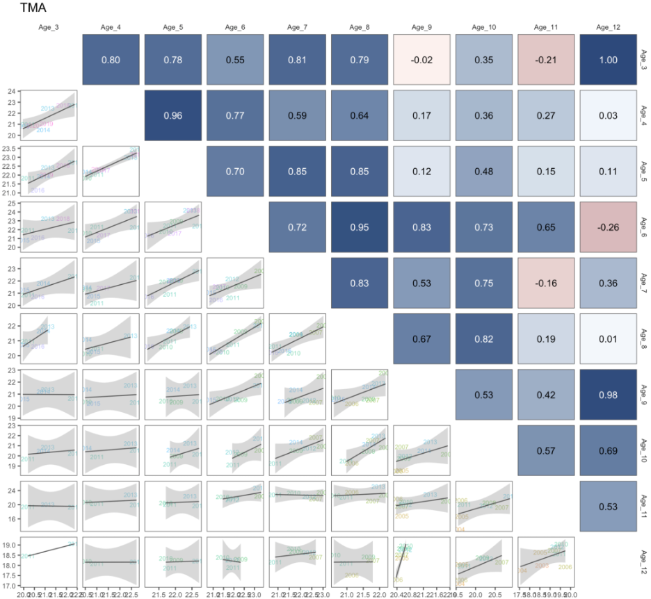

Figure 1: Cohort consistency over different ages based on log-abundance from the bottom-trawl survey data for pollock in recent years for traditional microscope age estimates. The cohorts are shown in the labels.

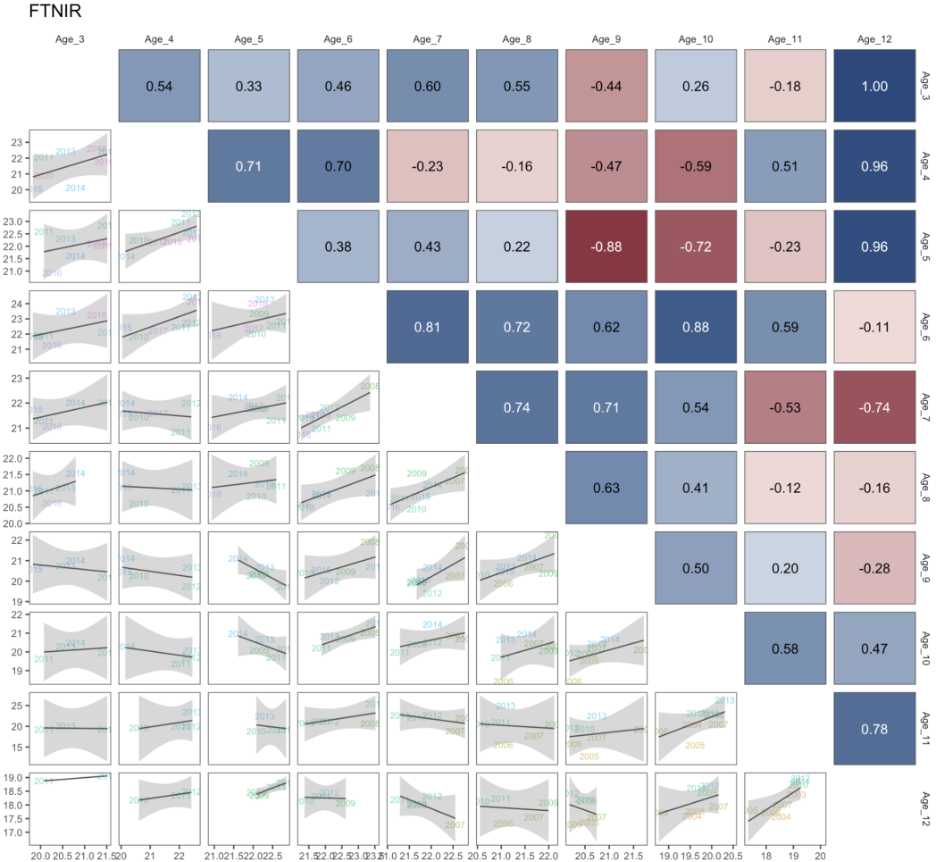

Figure 2: Cohort consistency over different ages based on log-abundance from the bottom-trawl survey data for pollock in recent years for FTNIRs age estimates. The cohorts are shown in the labels.

When preparing the data for the assessment, we plotted out the proportions-at-age for the TMA data and noted the differences in the estimates using the FTNIRs age estimates (Figure 3, Figure 4, and Figure 5). Other preparations involved estimating the age-determination errors for each method following that of Punt et al. (2008). For the FTNIRs data, we optionally estimated separate age-estimation error matrices by gear type. The appearance of the fleet-aggregated and fleet-specific input data files is shown in Figure 6.

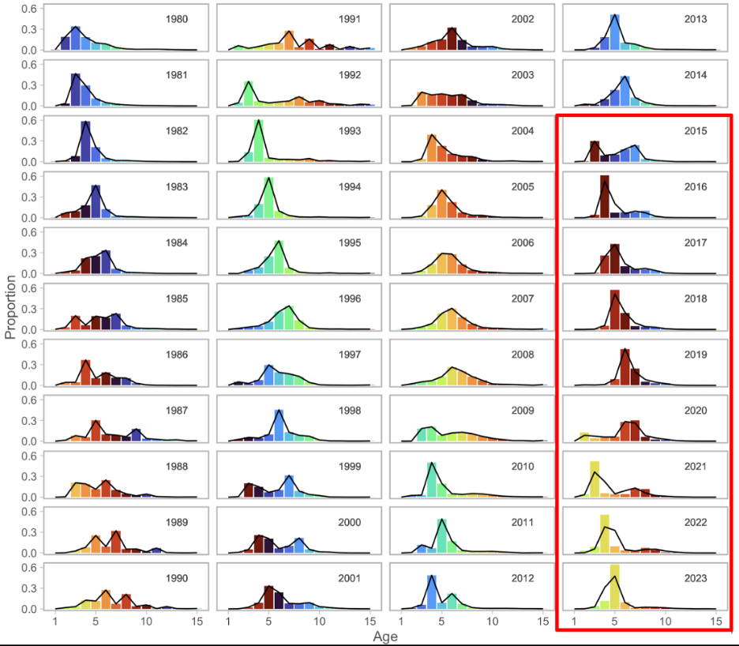

Figure 3: Proportions at age for recent years for the fishery data where the columns represent the traditional microscope age estimates (TMA) compared to the FTNIRs age estimates (lines for the red-outlined panels).

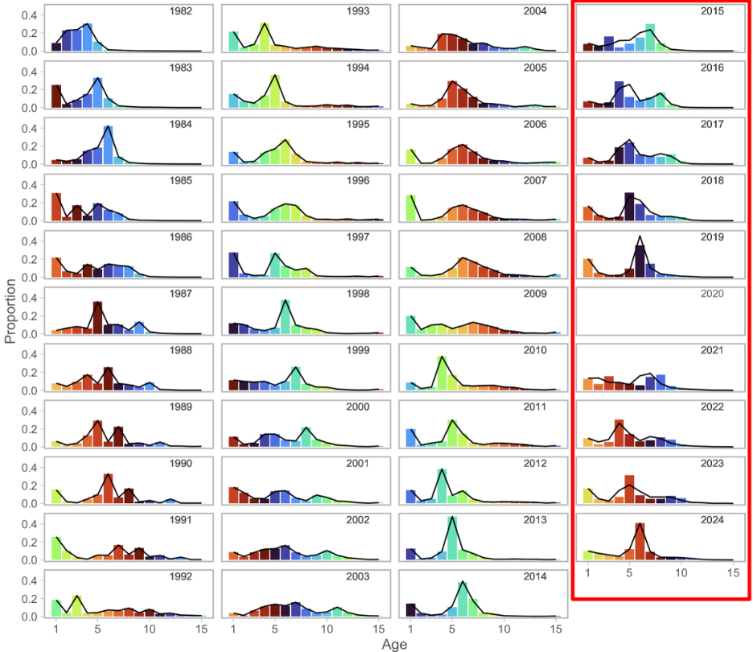

Figure 4: Proportions at age for recent years for the bottom-trawl survey data where the columns represent the traditional microscope age estimates (TMA) compared to the FTNIRs age estimates (lines for the red-outlined panels).

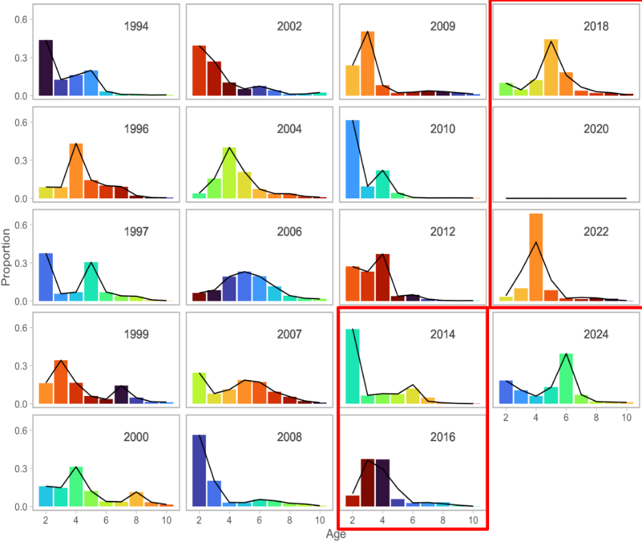

Figure 5: Proportions at age for recent years for the acoustic-trawl survey data where the columns represent the traditional microscope age estimates (TMA) compared to the FTNIRs age estimates (lines for the red-outlined panels).

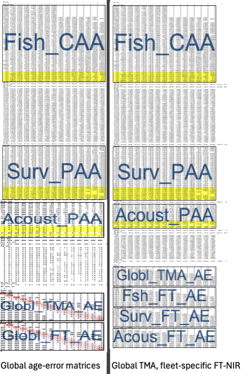

Figure 6: Schematic of input datafile showing the breakout of the fleet-specific FTNIRs age-error matrices (right panel) compared to that where the global FTNIRs age-error matrices are used (left panel).

For the assessment model, the alternatives are shown based on the coverage of data and availability among types of ageing is shown in Figure 7. These figures are intended to show what data are available for the model testing and the different ways of treating age determination error matrices.

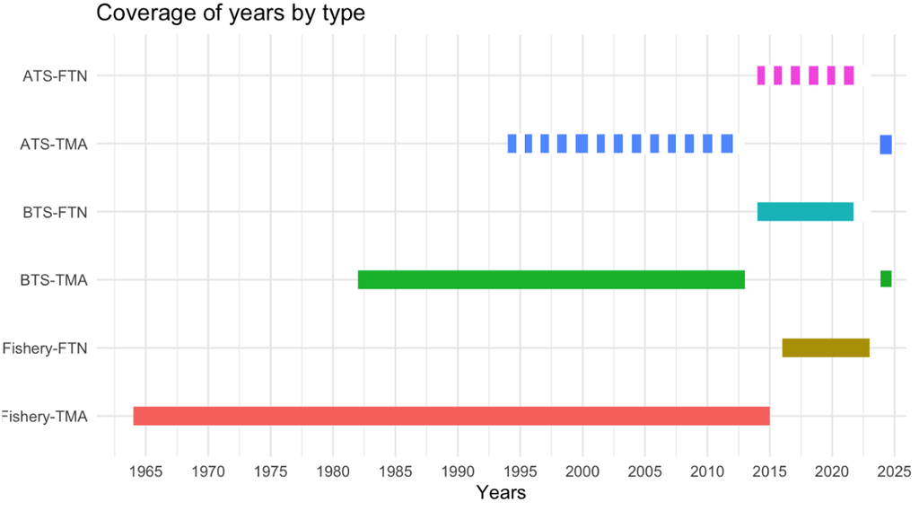

Figure 7: Data extent by age composition for the models with FTNIRs age estimates. The data types are for the Fishery, bottom trawl survey (BTS), and acoustic trawl survey (ATS) and the years of coverage are shown in the x-axis.

## Comparisons of fit to FT-NIRS models

| Name | Model description Age type | Model description Age-error |
| --- | --- | --- |
| Base | TMA | Global TMA |
| FT-NIR 1 | TMA + FT-NIR | Global TMA, global FT-NIR |
| FT-NIR 2 | TMA + FT-NIR | Global TMA, disaggregated FT-NIR |

Table 1: Configuration of different model options testing the impact of different treatment of the age composition data and ageing error.

| Component | Base | FT-NIR fleets aggregated | FT-NIR fleet-specific |
| --- | --- | --- | --- |
| RMSE BTS | 0.150 | 0.151 | 0.152 |
| RMSE ATS | 0.167 | 0.163 | 0.158 |
| RMSE AVO | 0.216 | 0.217 | 0.215 |
| RMSE CPUE | 0.097 | 0.097 | 0.097 |
| SDNR BTS | 0.890 | 0.900 | 0.880 |
| SDNR ATS | 0.930 | 0.910 | 0.880 |
| SDNR AVO | 0.950 | 0.960 | 0.940 |
| Eff. N Fishery | 358 | 336 | 381 |
| Eff. N BTS | 159 | 148 | 153 |
| Eff. N ATS | 233 | 221 | 233 |
| Catch NLL | 3 | 4 | 3 |
| BTS NLL | 24 | 24 | 23 |
| ATS NLL | 8 | 7 | 7 |
| ATS Age1 NLL | 7 | 8 | 9 |
| AVO NLL | 8 | 8 | 8 |
| Fish Age NLL | 417 | 559 | 614 |
| BTS Age NLL | 286 | 330 | 313 |
| ATS Age NLL | 43 | 42 | 41 |
| NLL selectivity | 213 | 216 | 215 |
| NLL Priors | 20 | 20 | 20 |
| Data NLL | 807 | 995 | 1,032 |
| Total NLL | 1110.900 | 1298.930 | 1332.810 |

Table 2: Goodness-of-fit measures to primary data for different data and age-error applications. RMSE=root-mean square log errors, NLL=negative log-likelihood, SDNR=standard deviation of normalized residuals, Eff. N=effective sample size for composition data). See text for incremental model descriptions.

| Component | Base | FT-NIR fleets aggregated | FT-NIR fleet-specific |
| --- | --- | --- | --- |
| ${B}_{2025}$ | 2,800 | 2,500 | 2,700 |
| $CV_{B_{2025}}$ | 0.14 | 0.14 | 0.14 |
| $B_{MSY}$ | 1,667 | 1,652 | 1,670 |
| $CV_{B_{MSY}}$ | 0.23 | 0.24 | 0.23 |
| ${B}_{2025}/B_{MSY}$ | 165% | 153% | 162% |
| $B_0$ | 4,318 | 4,360 | 4,436 |
| $B_{35\%}$ | 1,935 | 1,898 | 1,931 |
| SPR rate at $F_{MSY}$ | 31% | 30% | 29% |
| Steepness | 0.63 | 0.64 | 0.64 |
| Est. $B_{2024} / B_{2024,no fishing}$ | 0.65 | 0.62 | 0.64 |
| $B_{2024} / B_{MSY}$ | 182% | 169% | 178% |

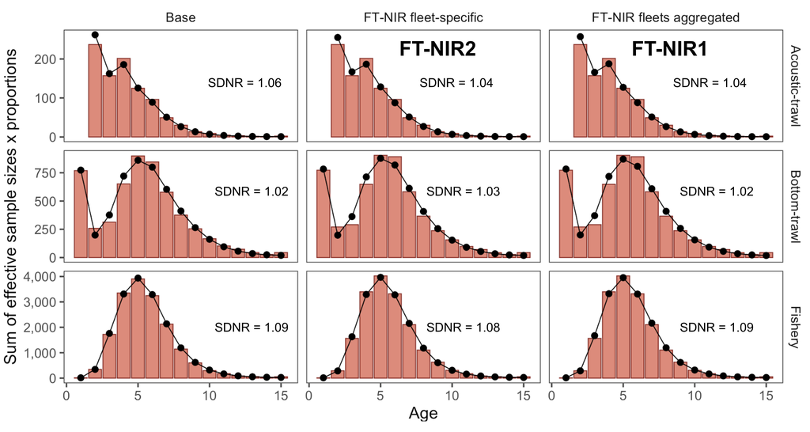

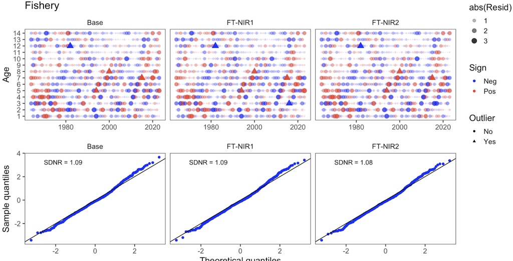

Figure 9: One-step ahead residuals for different model specifications for the fishery composition data

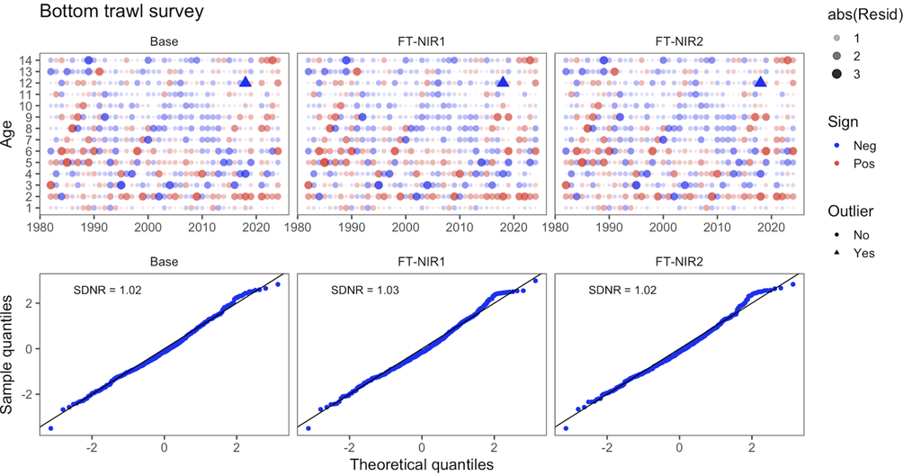

Figure 10: One-step ahead residuals for different model specifications for the bottom-trawl survey composition data

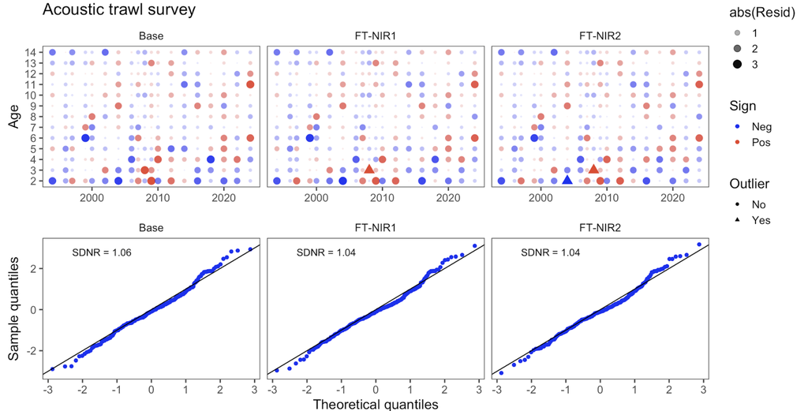

Figure 11: One-step ahead residuals for different model specifications for the acoustic-trawl survey composition data

# Leave-one-out survey sensitivity analysis

Here we present model runs that downweight one or more sources of survey data at a time. Table 4 shows the combinations of data types included for this analysis, which includes six model runs: (1) downweight all Acoustic Trawl Survey (ATS) data (age 1 survey index, age 2+ survey biomass index, and age composition data), (2) downweight the ATS age composition data, (3) downweight the Acoustic Vessels of Opportunity (AVO) data (survey biomass index), (4) downweight all Eastern Bering Sea Trawl Survey (BTS) data (age 1+ survey biomass index and age composition data), (5) downweight the BTS age composition data, and (6) downweight all survey biomass indices (BTS, ATS, and AVO survey biomass indices). The ATS age 1 data are included as a separate survey index in the assessment model, while BTS age 1 data are included with the age composition data in the multinomial objective function component.

[output not shown]

Table 4: Configuration of different model options testing the impact of different data components

Among these models, downweighting the BTS data (both solely downweighting the BTS age composition data and downweighting all BTS data) led to changes in trends over time in estimated spawning biomass Figure 12 . The model estimates of recruitment were variable across sensitivity runs, but estimates differed the most from the 2024 accepted model when all BTS data were downweighted Figure 13. Estimates of BTS survey biomass fit the BTS data very poorly in most years when the BTS data were downweighted (Figure 14). Additionally, the fits to the BTS survey biomass were affected by downweighting the BTS age composition data (without downweighting the BTS survey index). The model was relatively insensitive to other data being excluded, and fits to the ATS and AVO indices were relatively insensitive to downweighting the BTS data (see Figure 14, Figure 15, and Figure 16). The root mean square error (RMSE) in Table 5 for the model run that downweighted all BTS data was large and the and effective sample size (Eff. N) was low as compared to the 2024 accepted model. Additionally, downweighting solely the BTS age composition data led to low effective sample size for the BTS.

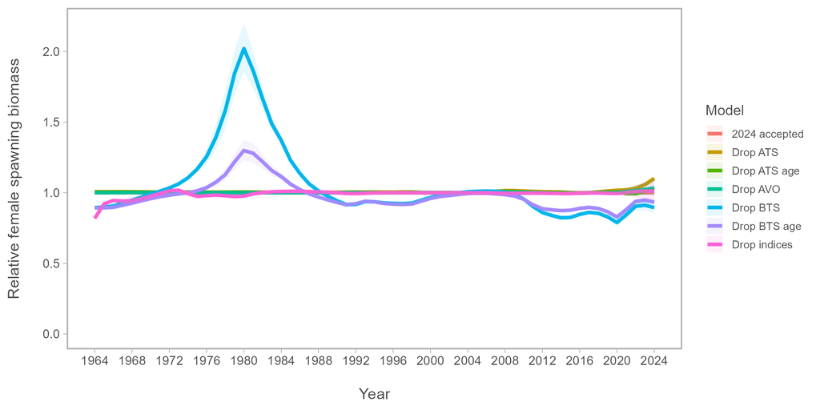

Figure 12: Comparison of spawning biomass (SSB) relative to the 2024 accepted model for models that downweight one data source at a time

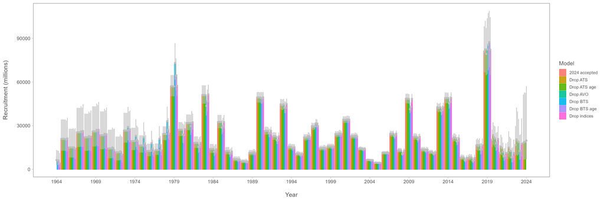

Figure 13: Comparison of recruitment estimates for models that downweight one data source at a time

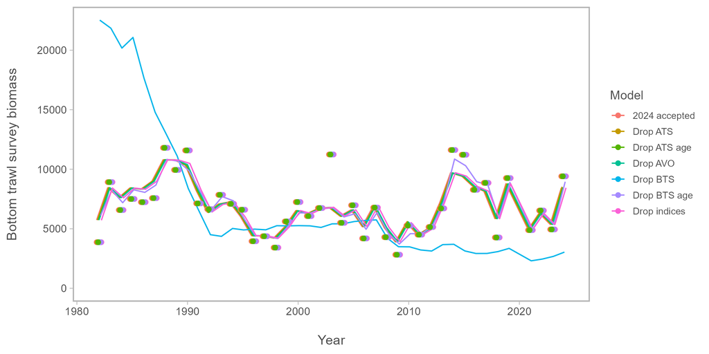

Figure 14: Comparison of fits to the Eastern Bering Sea Bottom Trawl Survey (BTS) biomass index for models that downweight one data source at a time

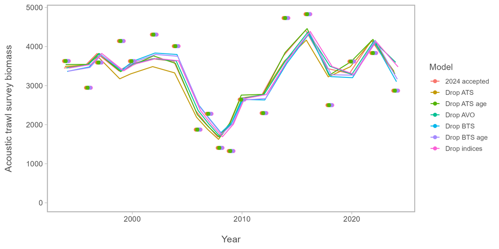

Figure 15: Comparison of fits to the Acoustic Trawl Survey (ATS) biomass index for models that downweight one data source at a time

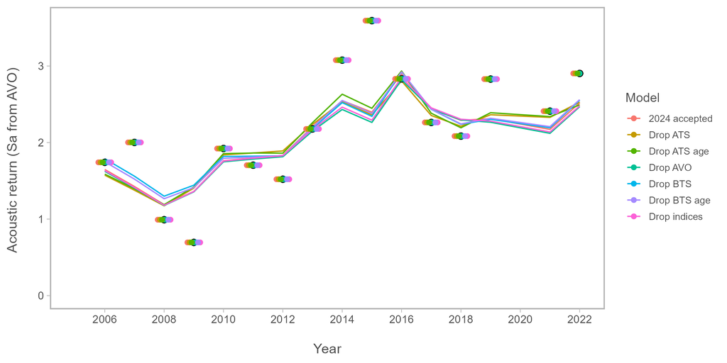

Figure 16: Comparison of fits to the Acoustic Vessels of Opportunity (AVO) biomass index for models that downweight one data source at a time

| Component | 2024 accepted | Drop BTS | Drop ATS | Drop AVO | Drop indices | Drop BTS age | Drop ATS age |
| --- | --- | --- | --- | --- | --- | --- | --- |
| RMSE BTS | 0.157 | 0.689 | 0.157 | 0.157 | 0.157 | 0.152 | 0.157 |
| RMSE ATS | 0.180 | 0.182 | 0.188 | 0.191 | 0.187 | 0.178 | 0.175 |
| RMSE AVO | 0.229 | 0.237 | 0.238 | 0.241 | 0.238 | 0.231 | 0.232 |
| RMSE CPUE | 0.093 | 0.090 | 0.093 | 0.093 | 0.098 | 0.092 | 0.093 |
| Eff. N Fishery | 1,182 | 1,379 | 1,190 | 1,185 | 1,176 | 1,344 | 1,196 |
| Eff. N BTS | 248 | 95 | 254 | 249 | 245 | 84 | 251 |
| Eff. N ATS | 269 | 230 | 164 | 269 | 273 | 228 | 158 |

Table 5: Goodness-of-fit measures to primary data for leave-one-out model sensitivity runs. RMSE=root-mean square log errors, SDNR=standard deviation of normalized residuals, Eff. N=effective sample size for composition data).

| Estimated Quantity | 2024 accepted | Drop BTS | Drop ATS | Drop AVO | Drop indices | Drop BTS age | Drop ATS age |
| --- | --- | --- | --- | --- | --- | --- | --- |
| ${B}_{2025}$ | 3,100 | 2,700 | 3,600 | 3,300 | 3,200 | 2,800 | 3,300 |
| $CV_{B_{2025}}$ | 0.13 | 0.16 | 0.14 | 0.16 | 0.18 | 0.15 | 0.13 |
| $B_{MSY}$ | 2,310 | 2,415 | 2,360 | 2,322 | 3,677 | 2,301 | 2,334 |
| $CV_{B_{MSY}}$ | 0.3 | 0.31 | 0.31 | 0.31 | 1.26 | 0.32 | 0.31 |
| ${B}_{2025}/B_{MSY}$ | 135% | 111% | 151% | 141% | 86% | 123% | 142% |
| $B_0$ | 5,975 | 6,136 | 6,120 | 6,009 | 8,934 | 5,904 | 6,050 |
| $B_{35\%}$ | 2,066 | 1,988 | 2,101 | 2,080 | 2,074 | 1,994 | 2,082 |
| SPR rate at $F_{MSY}$ | 31% | 35% | 31% | 31% | 42% | 33% | 31% |
| Steepness | 0.62 | 0.59 | 0.62 | 0.62 | 0.52 | 0.61 | 0.62 |
| Est. $B_{2024} / B_{2024,no fishing}$ | 0.61 | 0.51 | 0.63 | 0.61 | 0.42 | 0.56 | 0.61 |
| $B_{2024} / B_{MSY}$ | 147% | 126% | 158% | 151% | 93% | 138% | 150% |

Table 6: Estimated derived quantities and selected corresponding CVs for leave-one-out sensitivity analysis runs. See text for incremental model descriptions.

# Incorporating multi-species M-at-age and year estimates

A commonly adopted approach is to use estimated natural mortality-at-age and year from multispecies trophic interaction models (e.g., Trijoulet, Fay, and Miller (2020)). The current assessment has an option to include the 2024 CEATTLE estimates of natural mortality (Table 7; Figure 17). This resulted in slightly higher

recruitment (Figure 18) lower spawning biomass in the near term (Figure 19). This is due to the higher natural mortality for most ages and years compared to the base 2024 model.

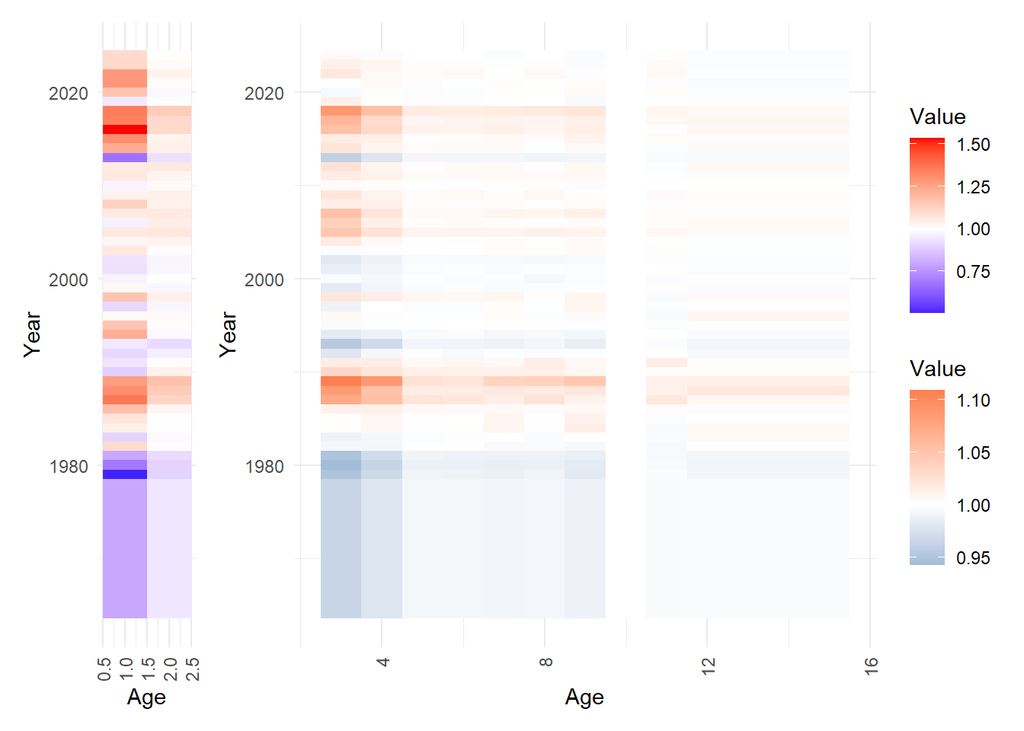

Figure 17: Depiction of the natural mortality (variability from mean value at age) as estimated from CEATTLE.

|  | 1 | 2 | 3 | 4 | 5 | 6 | 7 | 8 | 9 | 10 |
| --- | --- | --- | --- | --- | --- | --- | --- | --- | --- | --- |
| 1964 | 1.024 | 0.341 | 0.320 | 0.311 | 0.303 | 0.304 | 0.303 | 0.304 | 0.304 | 0.3001 |
| 1965 | 1.024 | 0.341 | 0.320 | 0.311 | 0.303 | 0.304 | 0.303 | 0.304 | 0.304 | 0.3001 |
| 1966 | 1.024 | 0.341 | 0.320 | 0.311 | 0.303 | 0.304 | 0.303 | 0.304 | 0.304 | 0.3001 |
| 1967 | 1.024 | 0.341 | 0.320 | 0.311 | 0.303 | 0.304 | 0.303 | 0.304 | 0.304 | 0.3001 |
| 1968 | 1.024 | 0.341 | 0.320 | 0.311 | 0.303 | 0.304 | 0.303 | 0.304 | 0.304 | 0.3001 |
| 1969 | 1.024 | 0.341 | 0.320 | 0.311 | 0.303 | 0.304 | 0.303 | 0.304 | 0.304 | 0.3001 |
| 1970 | 1.024 | 0.341 | 0.320 | 0.311 | 0.303 | 0.304 | 0.303 | 0.304 | 0.304 | 0.3001 |
| 1971 | 1.024 | 0.341 | 0.320 | 0.311 | 0.303 | 0.304 | 0.303 | 0.304 | 0.304 | 0.3001 |
| 1972 | 1.024 | 0.341 | 0.320 | 0.311 | 0.303 | 0.304 | 0.303 | 0.304 | 0.304 | 0.3001 |
| 1973 | 1.024 | 0.341 | 0.320 | 0.311 | 0.303 | 0.304 | 0.303 | 0.304 | 0.304 | 0.3001 |
| 1974 | 1.024 | 0.341 | 0.320 | 0.311 | 0.303 | 0.304 | 0.303 | 0.304 | 0.304 | 0.3001 |
| 1975 | 1.024 | 0.341 | 0.320 | 0.311 | 0.303 | 0.304 | 0.303 | 0.304 | 0.304 | 0.3001 |
| 1976 | 1.024 | 0.341 | 0.320 | 0.311 | 0.303 | 0.304 | 0.303 | 0.304 | 0.304 | 0.3001 |
| 1977 | 1.024 | 0.341 | 0.320 | 0.311 | 0.303 | 0.304 | 0.303 | 0.304 | 0.304 | 0.3001 |
| 1978 | 1.024 | 0.341 | 0.320 | 0.311 | 0.303 | 0.304 | 0.303 | 0.304 | 0.304 | 0.3001 |
| 1979 | 0.644 | 0.326 | 0.315 | 0.308 | 0.303 | 0.303 | 0.302 | 0.303 | 0.302 | 0.3001 |
| 1980 | 0.883 | 0.325 | 0.313 | 0.307 | 0.302 | 0.302 | 0.302 | 0.303 | 0.302 | 0.3001 |
| 1981 | 1.022 | 0.333 | 0.315 | 0.309 | 0.303 | 0.303 | 0.303 | 0.303 | 0.303 | 0.3001 |
| 1982 | 1.415 | 0.365 | 0.329 | 0.316 | 0.305 | 0.306 | 0.305 | 0.305 | 0.305 | 0.3001 |
| 1983 | 1.156 | 0.358 | 0.328 | 0.316 | 0.305 | 0.306 | 0.306 | 0.305 | 0.307 | 0.3001 |
| 1984 | 1.342 | 0.363 | 0.332 | 0.320 | 0.305 | 0.306 | 0.308 | 0.306 | 0.312 | 0.3001 |
| 1985 | 1.380 | 0.362 | 0.331 | 0.320 | 0.306 | 0.306 | 0.308 | 0.307 | 0.311 | 0.3001 |
| 1986 | 1.517 | 0.371 | 0.336 | 0.322 | 0.307 | 0.307 | 0.308 | 0.307 | 0.309 | 0.3001 |
| 1987 | 1.756 | 0.406 | 0.356 | 0.335 | 0.312 | 0.312 | 0.310 | 0.314 | 0.311 | 0.3001 |
| 1988 | 1.684 | 0.415 | 0.360 | 0.335 | 0.310 | 0.311 | 0.312 | 0.312 | 0.314 | 0.3001 |
| 1989 | 1.632 | 0.425 | 0.368 | 0.346 | 0.313 | 0.313 | 0.317 | 0.318 | 0.322 | 0.3001 |
| 1990 | 1.145 | 0.377 | 0.343 | 0.325 | 0.309 | 0.310 | 0.309 | 0.311 | 0.309 | 0.3001 |
| 1991 | 1.206 | 0.365 | 0.337 | 0.323 | 0.307 | 0.308 | 0.307 | 0.311 | 0.309 | 0.3001 |
| 1992 | 1.169 | 0.348 | 0.325 | 0.316 | 0.305 | 0.305 | 0.305 | 0.305 | 0.307 | 0.3001 |
| 1993 | 1.220 | 0.332 | 0.316 | 0.309 | 0.303 | 0.303 | 0.303 | 0.304 | 0.303 | 0.3001 |
| 1994 | 1.576 | 0.357 | 0.326 | 0.315 | 0.304 | 0.305 | 0.304 | 0.305 | 0.305 | 0.3001 |
| 1995 | 1.493 | 0.365 | 0.331 | 0.318 | 0.306 | 0.306 | 0.306 | 0.307 | 0.307 | 0.3001 |
| 1996 | 1.306 | 0.367 | 0.334 | 0.318 | 0.305 | 0.306 | 0.307 | 0.306 | 0.309 | 0.3001 |
| 1997 | 1.168 | 0.355 | 0.328 | 0.318 | 0.305 | 0.305 | 0.307 | 0.306 | 0.310 | 0.3001 |
| 1998 | 1.492 | 0.377 | 0.338 | 0.323 | 0.308 | 0.308 | 0.308 | 0.307 | 0.310 | 0.3001 |
| 1999 | 1.311 | 0.355 | 0.326 | 0.316 | 0.304 | 0.306 | 0.305 | 0.306 | 0.307 | 0.3001 |
| 2000 | 1.249 | 0.362 | 0.330 | 0.316 | 0.305 | 0.305 | 0.305 | 0.305 | 0.306 | 0.3001 |
| 2001 | 1.194 | 0.355 | 0.327 | 0.316 | 0.305 | 0.305 | 0.305 | 0.306 | 0.306 | 0.3001 |
| 2002 | 1.199 | 0.353 | 0.325 | 0.315 | 0.304 | 0.305 | 0.305 | 0.305 | 0.306 | 0.3001 |
| 2003 | 1.367 | 0.364 | 0.331 | 0.319 | 0.305 | 0.306 | 0.306 | 0.307 | 0.309 | 0.3001 |
| 2004 | 1.312 | 0.374 | 0.337 | 0.320 | 0.306 | 0.306 | 0.306 | 0.306 | 0.308 | 0.3001 |
| 2005 | 1.366 | 0.387 | 0.348 | 0.326 | 0.308 | 0.309 | 0.309 | 0.310 | 0.310 | 0.3001 |
| 2006 | 1.243 | 0.380 | 0.345 | 0.323 | 0.306 | 0.307 | 0.307 | 0.307 | 0.308 | 0.3001 |
| 2007 | 1.355 | 0.385 | 0.349 | 0.325 | 0.307 | 0.307 | 0.309 | 0.309 | 0.311 | 0.3001 |
| 2008 | 1.450 | 0.377 | 0.336 | 0.322 | 0.306 | 0.307 | 0.307 | 0.307 | 0.308 | 0.3001 |
| 2009 | 1.328 | 0.378 | 0.339 | 0.321 | 0.306 | 0.308 | 0.306 | 0.308 | 0.307 | 0.3001 |
| 2010 | 1.250 | 0.368 | 0.333 | 0.319 | 0.306 | 0.306 | 0.306 | 0.307 | 0.307 | 0.3001 |
| 2011 | 1.361 | 0.374 | 0.336 | 0.322 | 0.307 | 0.307 | 0.307 | 0.308 | 0.309 | 0.3001 |
| 2012 | 1.358 | 0.384 | 0.340 | 0.321 | 0.306 | 0.307 | 0.307 | 0.306 | 0.309 | 0.3001 |
| 2013 | 0.863 | 0.337 | 0.319 | 0.311 | 0.303 | 0.304 | 0.304 | 0.304 | 0.305 | 0.3001 |
| 2014 | 1.586 | 0.378 | 0.339 | 0.321 | 0.307 | 0.307 | 0.307 | 0.306 | 0.309 | 0.3001 |
| 2015 | 1.688 | 0.375 | 0.337 | 0.323 | 0.306 | 0.307 | 0.307 | 0.307 | 0.310 | 0.3001 |
| 2016 | 1.975 | 0.401 | 0.349 | 0.328 | 0.309 | 0.309 | 0.310 | 0.309 | 0.311 | 0.3001 |
| 2017 | 1.726 | 0.402 | 0.352 | 0.328 | 0.308 | 0.309 | 0.309 | 0.309 | 0.311 | 0.3001 |
| 2018 | 1.738 | 0.413 | 0.361 | 0.335 | 0.310 | 0.310 | 0.311 | 0.312 | 0.314 | 0.3001 |
| 2019 | 1.218 | 0.364 | 0.336 | 0.319 | 0.306 | 0.307 | 0.306 | 0.306 | 0.306 | 0.3001 |
| 2020 | 1.497 | 0.356 | 0.330 | 0.319 | 0.305 | 0.305 | 0.306 | 0.307 | 0.309 | 0.3001 |
| 2021 | 1.656 | 0.365 | 0.332 | 0.319 | 0.306 | 0.306 | 0.307 | 0.306 | 0.308 | 0.3001 |
| 2022 | 1.649 | 0.375 | 0.338 | 0.320 | 0.306 | 0.308 | 0.306 | 0.308 | 0.307 | 0.3001 |
| 2023 | 1.421 | 0.367 | 0.336 | 0.321 | 0.306 | 0.307 | 0.306 | 0.307 | 0.307 | 0.3001 |
| 2024 | 1.417 | 0.361 | 0.333 | 0.318 | 0.305 | 0.306 | 0.305 | 0.306 | 0.306 | 0.3001 |

Table 7: Natural mortality-at-age used over ages and time based on the CEATTLE 2024 model.

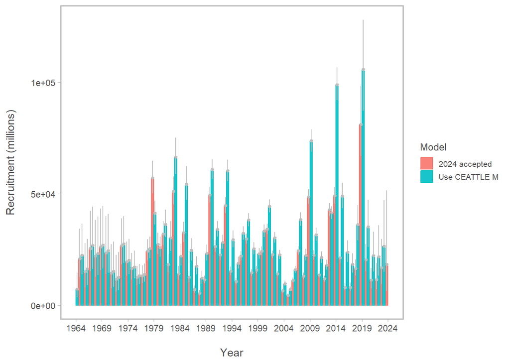

Figure 18: Comparison of recruitment estimates comparing 2024 assessment results with one where M-at-age and year is specified from CEATTLE.

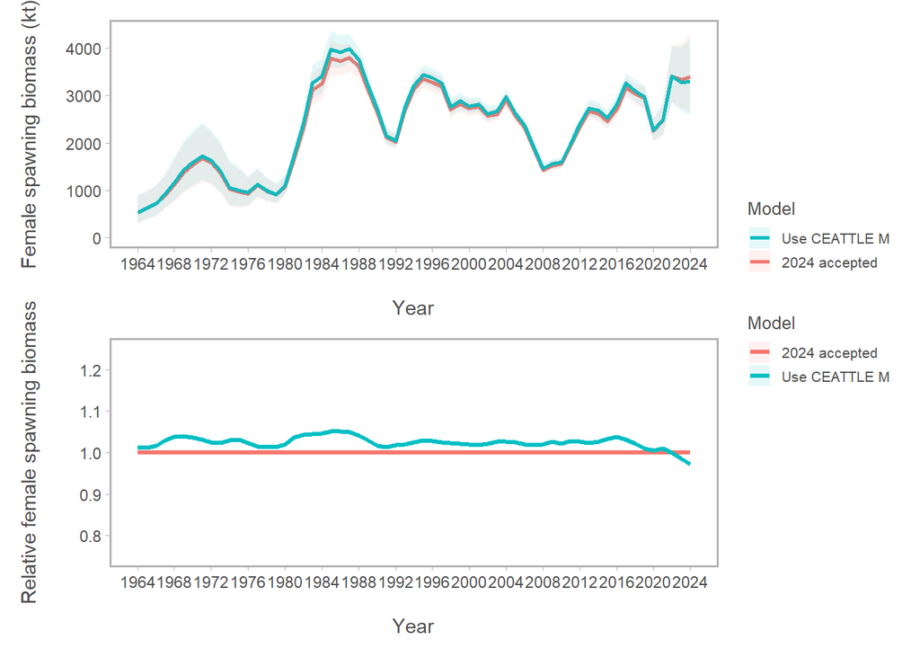

Figure 19: Comparison of spawning biomass (SSB) and SSB relative to the 2024 accepted model for model that uses the M-at-age matrix from CEATTLE.

| Component | 2024 accepted | Use CEATTLE M |
| --- | --- | --- |
| RMSE BTS | 0.157 | 0.157 |
| RMSE ATS | 0.180 | 0.179 |
| RMSE AVO | 0.229 | 0.230 |
| RMSE CPUE | 0.093 | 0.093 |
| SDNR BTS | 0.950 | 0.960 |
| SDNR ATS | 1.000 | 0.990 |
| SDNR AVO | 0.980 | 0.960 |
| Eff. N Fishery | 1,182 | 1,176 |
| Eff. N BTS | 248 | 241 |
| Eff. N ATS | 269 | 267 |
| Catch NLL | 3 | 3 |
| BTS NLL | 31 | 31 |
| ATS NLL | 9 | 9 |
| ATS Age1 NLL | 11 | 12 |
| AVO NLL | 9 | 8 |
| Fish Age NLL | 167 | 168 |
| BTS Age NLL | 194 | 196 |
| ATS Age NLL | 30 | 31 |
| NLL selectivity | 196 | 196 |
| NLL Priors | 20 | 20 |
| Data NLL | 465 | 468 |
| Total NLL | 718 | 713 |

Table 8: Goodness-of-fit measures to primary data for model sensitivity to applying the matrix of M-at-age and year instead of constant M-at-age. RMSE=root-mean square log errors, SDNR=standard deviation of normalized residuals, Eff. N=effective sample size for composition data).

| Estimated Quantity | 2024 accepted | Use CEATTLE M |
| --- | --- | --- |
| ${B}_{2025}$ | 3,100 | 3,000 |
| $CV_{B_{2025}}$ | 0.13 | 0.13 |
| $B_{MSY}$ | 2,310 | 2,584 |
| $CV_{B_{MSY}}$ | 0.3 | 0.35 |
| ${B}_{2025}/B_{MSY}$ | 135% | 116% |
| $B_0$ | 5,975 | 6,568 |
| $B_{35\%}$ | 2,066 | 1,844 |
| SPR rate at $F_{MSY}$ | 31% | 35% |
| Steepness | 0.62 | 0.59 |
| Est. $B_{2024} / B_{2024,no fishing}$ | 0.61 | 0.54 |
| $B_{2024} / B_{MSY}$ | 147% | 127% |

Table 9: Estimated derived quantities and selected corresponding CVs for sensitivity to natural mortality specification.

# Alternative assessment software

## Stock-synthesis 3

Stock synthesis 3 (SS3) is a well establish framework and is common in many diverse settings. (Methot and Wetzel (2013)) For EBS pollock, we extended an initial framework based on the configurations used for Pacific hake (Grandin et al. (2024)) since there are many similarities in the type of data available. Namely, empirical weight-at-age, acoustic survey data, and indices of 1-year olds.

Within the SS3 framework, we evaluated different configurations for fishery selectivity variability (Figure 20). These showed the impact on the uncertainty and stock trends (Figure 21 for SSB and Figure 22 for recruitment).

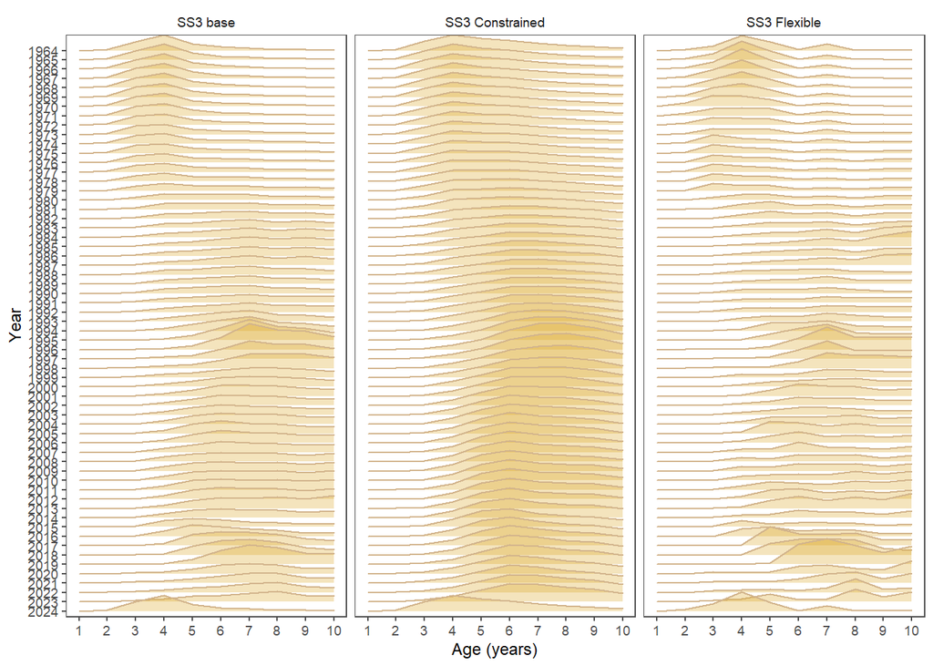

Figure 20: Model results comparing three different SS3 model configurations. The models are the base model (Base), the constrained model (Constrained), and the flexible model (Flexible).

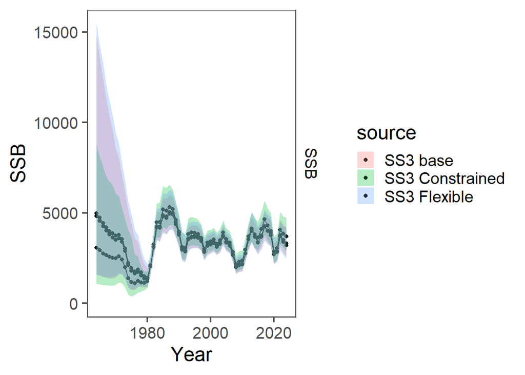

Figure 21: Model results comparing the time-series for three different SS3 model configurations. The models are the base model (Base), the constrained model (Constrained), and the flexible model (Flexible).

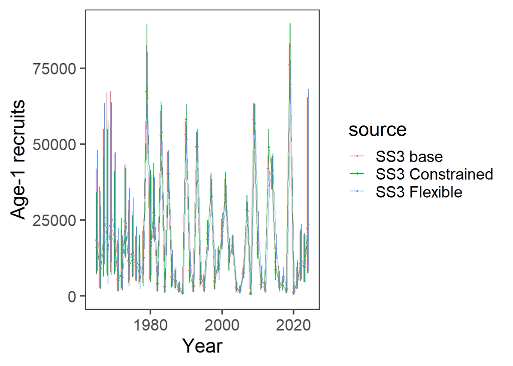

Figure 22: Model results comparing the time-series for three different SS3 model configurations. The models are the base model (Base), the constrained model (Constrained), and the flexible model (Flexible).

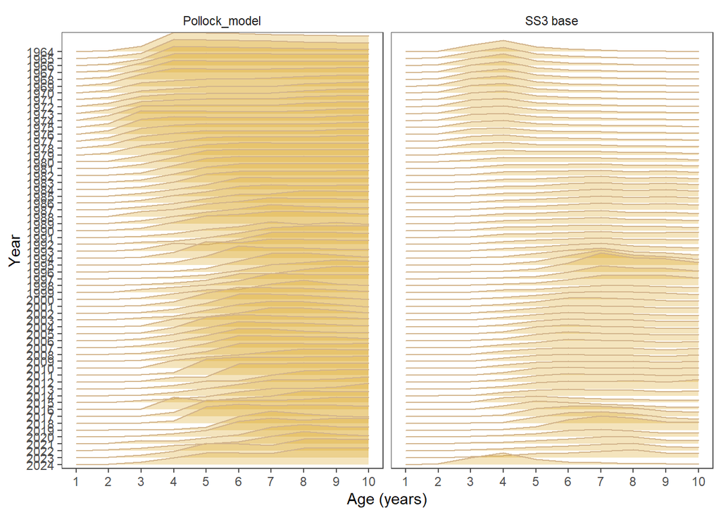

Figure 23: Model results comparing selectivity estimates between the base SS3 model configuration and the pollock model accepted in 2024.

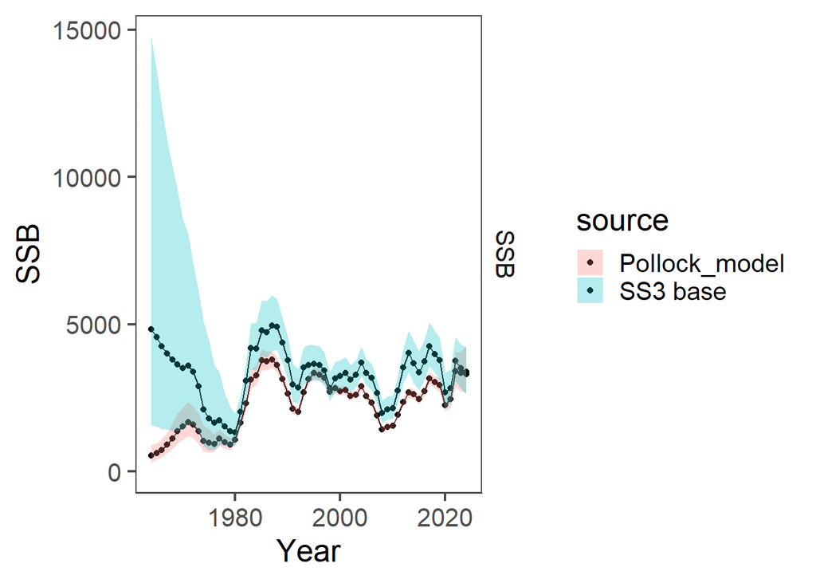

Figure 24: Model results comparing the base SS3 model configuration with the model used for pollock in 2024.

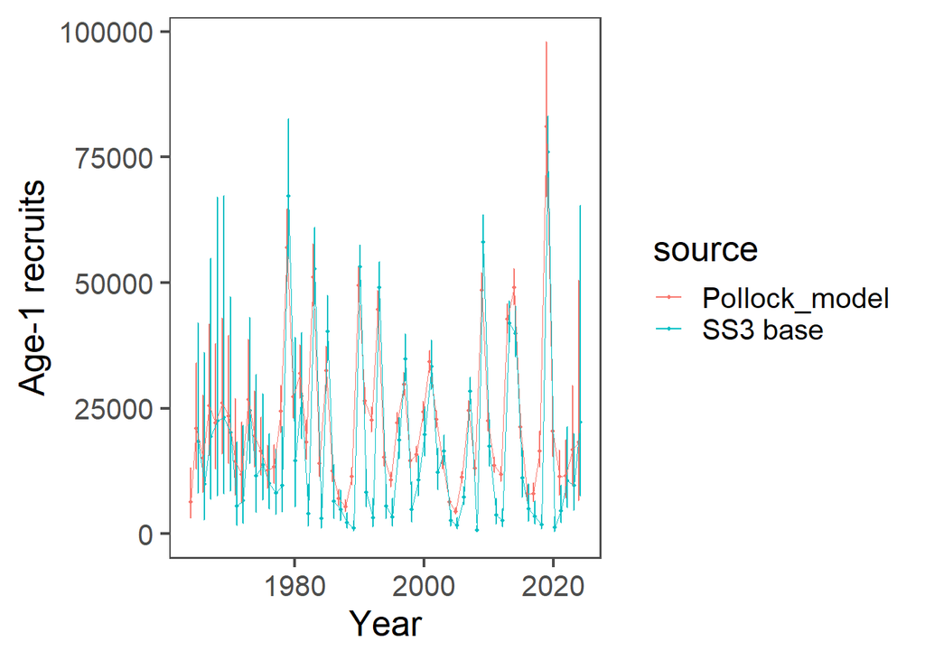

Figure 25: Model results comparing the base SS3 model configuration with the model used for pollock in 2024.

## SAM

The Stock Assessment Model (SAM) is a state-space model written in TMB (Nielsen and Berg (2014), Nielsen et al. (2021)). We attempted to configure the settings to have similar levels of flexibility to the reference model used for catch advice in 2024 and the settings and results can be found [here](https://github.com/noaa-afsc/EBS_pollock/tree/main/runs/SAM/poll24)). Comparing “selectivity” in the SAM model to the reference model, we see broad similarities but slightly lower inter-annual variability in the SAM run (Figure 26).

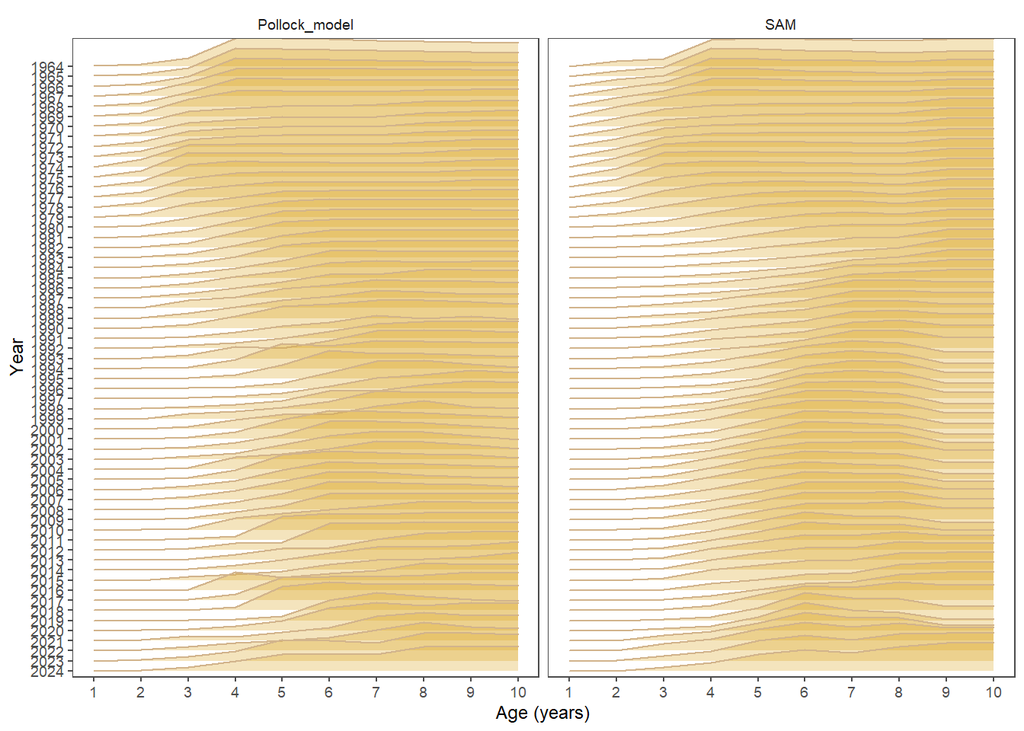

Figure 26: Model results comparing last year’s model with the SAM model.

The spawning biomass trend largely overlaps in the uncertainty between the SAM and pollock model (Figure 27). The recruitment estimates are similar as well (Figure 28).

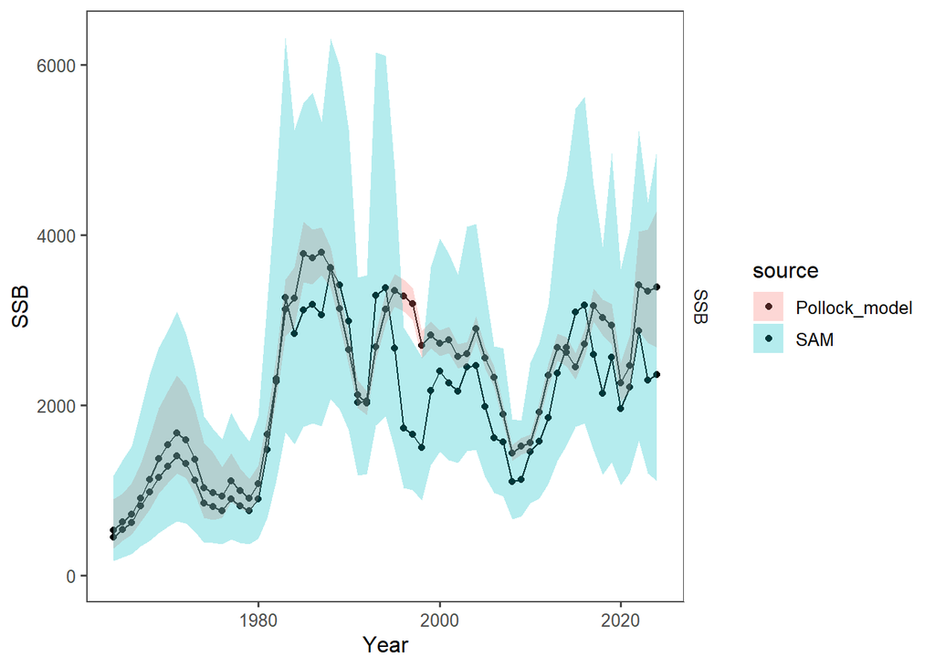

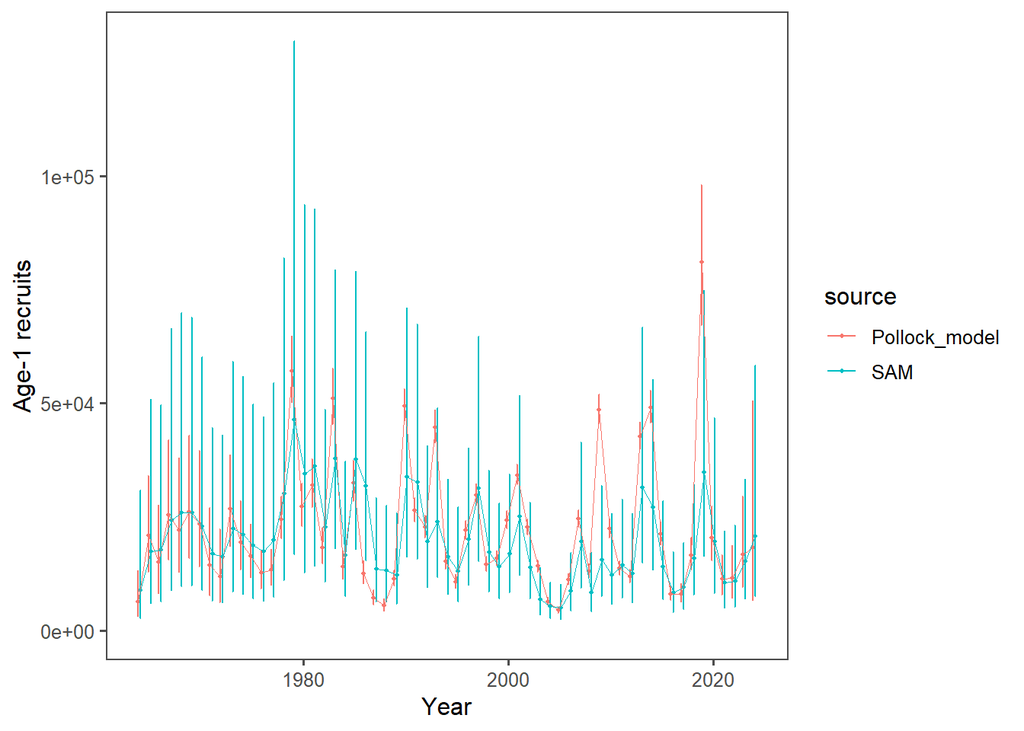

## Other models in development

The “Woods Hole Assessment model” (WHAM) is written in TMB and is a fully state-space model (Stock and Miller (2021)). Initial trials are available on the [github repository](https://github.com/noaa-afsc/EBS_pollock/tree/main/runs/wham).

The Rceattle model is developed by the AFSC and is written in TMB (Adams et al. (2022)). The model is an extension of the ADMB version used for multi-species model in the Eastern Bering Sea (Jurado-Molina, Livingston, and Ianelli (2005), Holsman et al. (2024)) and has a number of newer features. It is generalizable to include a variety of data types using lengths and can be set up for species tracked for sexual dimorphic growth and other processes. Since it has been recast into TMB, it allows for the ability to specify random effects in a number of processes. One development of the model is to have the flexibility to bridge among extant single-species modeling platforms by using it in “single-species” mode. To illustrate that, we introduce an application of Rceattle to the EBS pollock data set. The model is not yet fully developed, but we present preliminary results for consideration. Initial runs are favorable but further work is needed to bridge the selectivity options.

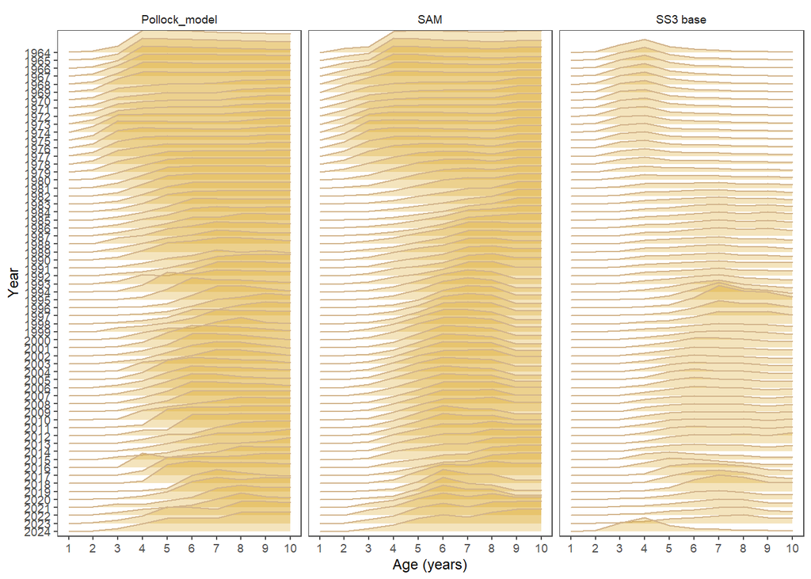

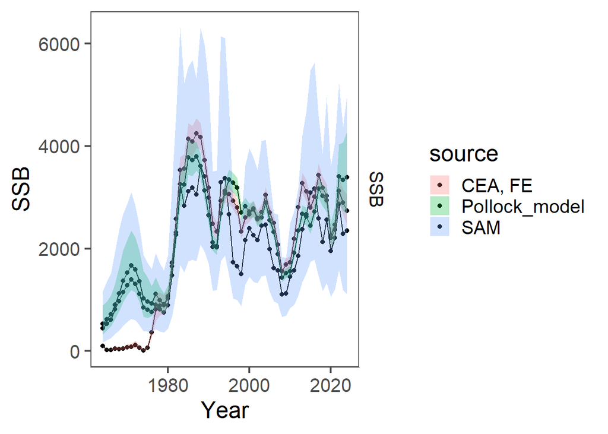

Figure 30: Model results comparing last year’s model with the Rceattle model.

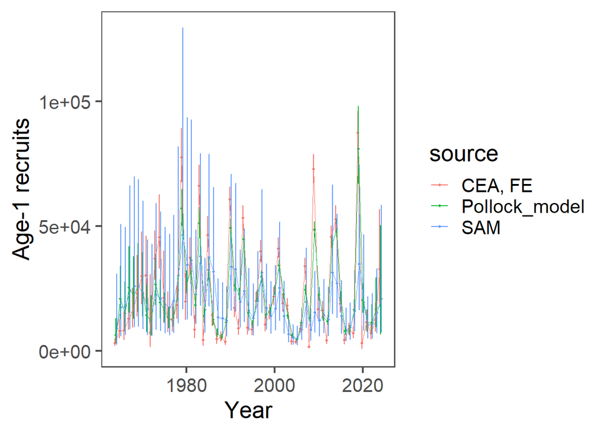

Figure 31: Model results comparing last year’s model with the Rceattle model.